# Intro to Analysis

Ben Chu

March 4, 2018

# This is a brief introduction into data analysis.

In this small handout, I will explain how to do basic data cleaning and analysis. This instruction is meant to show you how data scientists approach turning data into usable information. I want to further preface by saying there are many ways to clean data but this way is fairly fast and clean.

# First things to do is to find the data itself.

If you are using Google forms, please open the survey and switch over to the response section (next to questions) and click on the green icon next to the vertical dots.

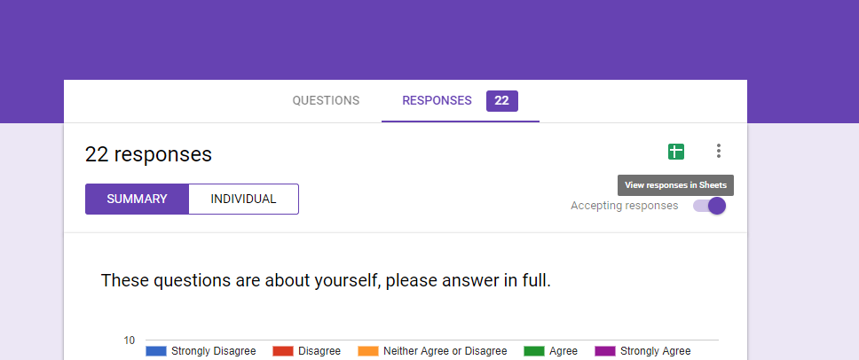

Great!

It’s your data! #Next thing we want to do is to make the variables we are using less complicated. We want to turn items into less confusing names because `"These.questions.are.about.yourself..please.answer.in.full...I.cried.many.times.this.year."` is a really long unecessary item. THANKS GOOGLE

#### This is usually row number 1, which is considered the headers for many data programs and sheets.

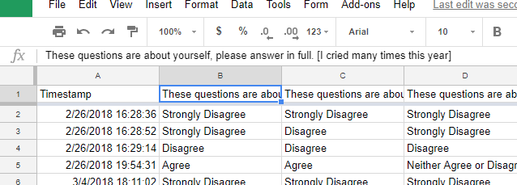

## Go ahead and just replace it with a shortened version of your variable name. And keep doing so for all your variables.

[figure not shown]

Great ##

# Let’s turn some characters into numerics.

Now that we have understandable names, we need to create understandable and analyzable responses. This is because character codes can’t be compared to each other.

Find the Edit dropdown and click “find and replace” or Ctrl+H

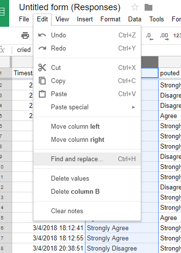

#### Great, it should pop up a box with information. Please first select “Match entire cell contents”.

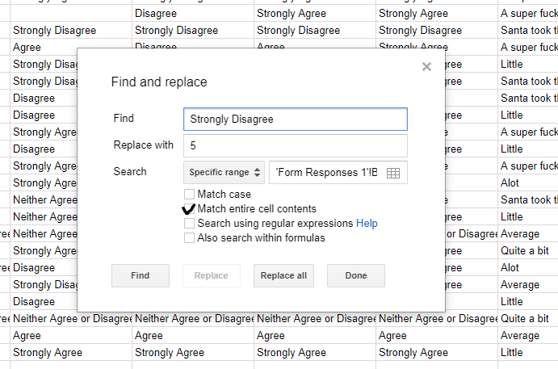

If you are using a Likert type scale, you would want  
Strongly Disagree = 1 Disagree = 2 Neither Agree nor Disagree = 3 Agree = 4 Strongly Agree = 5

*note* If you have negatively worded items, you might want to reverse code them at this point. This means if an item is worded in this fashion `I do not think I am great`

The scale would be the opposite. Strongly Disagree = 5 Disagree = 4 Neither Agree nor Disagree = 3 Agree = 2 Strongly Agree = 1

[figure not shown]

Whew, that’s alot of copy and pasting.

### Now we wanto do download it as a .csv and upload it into Rstudio.

File>download as> comma seperated value.

[figure not shown]

Next thing to do is to important it into your environment. My file ended up being saved as `Santa.Correlation.csv`

# Rstudio and data analysis

### We want to import our data into Rstudio so we can run correlations and etc.

[figure not shown]

You can also do this via the command line.

```r
Santa.Correlation <- read.csv("C:/Users/Branly Mclanbry/Desktop/Santa.Correlation.csv", header=TRUE)
```

Nice! it should appear in your global environment

[figure not shown]

## The first thing we want to do is to install and activate some packages.

Packages are pre-built user submitted functions that makes life easier. An analogy would be like buying furniture from IKEA. They provide you with everything you need to do what you want, you simply need to follow instructions.

You can install it via the point and click install, but most people prefer to install it via the command line. The `tidyverse` package comes from a genius called `Hadley Wickham`. He’s a r rockstar, a `r`ockstar because he essentially brainchilded code that makes it easier for people to understand and utilize. If I ever see him in public and I’m going to shake his hand and have him sign my forehead.

```r
install.packages("tidyverse")
```

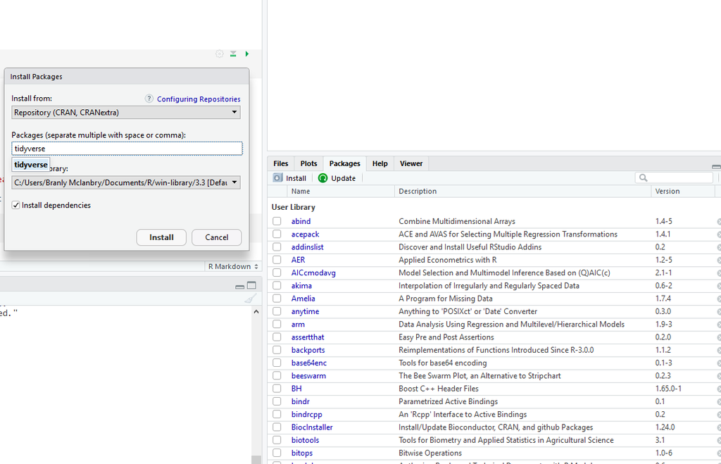

### Nice!You can activate the package by using this function.

```r
library(tidyverse)
```

From the `tidyverse` package, we want to use functions to create new variables based on previous variables.

The `%>%` functions basically means “and then”“.  
The `mutate` function tells us to create a new variable based on previous inputs.  
So the function below is telling us several things.”Please create a new variable called `niceness` using the information from `Santa.Correlation`.

## Composite scores.

We can create a composite variable that is a combination of the items together. For example, we want to know the total niceness of a child on christmas night. It’s the total of nice items divided by the number of nice items.

```r
Santa.Correlation <- Santa.Correlation %>%
  mutate(niceness = (cried + pouted + naughty + nice + bad + good + goodness4)/7)
```

Nice!  
Now let’s do it for our two scales.

```r
Santa.Correlation <- Santa.Correlation %>%
  mutate(niceness = (cried + pouted + naughty + nice + bad + good + goodness4)/7,
         somanygifts = (horns + drums + stockings + gifts)/4)
```

Cool bean! Now we have composite scores.

```r
psych::describe(Santa.Correlation$niceness)
```

```
##    vars  n mean   sd median trimmed  mad  min  max range skew kurtosis
## X1    1 22 3.24 0.75   3.36    3.23 0.85 2.14 4.43  2.29 0.06    -1.32
##      se
## X1 0.16
```

```r
psych::describe(Santa.Correlation$somanygifts)
```

```
##    vars  n mean   sd median trimmed  mad min max range skew kurtosis   se
## X1    1 26 3.62 1.96    3.5    3.64 2.78   1   6     5    0    -1.69 0.38
```

## Reliability

We want to know about the internal reliability of our items. This concept gets at the idea of “are each items measuring what they are supposed to be mesuring?” For example, If I wanted to ask questions of how nice a child was, I would want to ask questions like “how nice are you” or “have you been good?”. Asking a question like “What do you think about the color purple” might not be the best construct to ask for niceness.

```r
naughtynicelist <- Santa.Correlation %>%
  select(nice,good,goodness4,cried,pouted,naughty,bad)
```

Super! How about another list for our overall gifts?

```r
overallgifts <- Santa.Correlation %>%
  select(horns, drums, stockings, gifts)
```

Now let’s look at the total Cronbach’s Alpha, but first we need to load the package `psych`.

```r
library(psych)
alpha(naughtynicelist)
```

```
## Some items ( cried ) were negatively correlated with the total scale and
## probably should be reversed.
## To do this, run the function again with the 'check.keys=TRUE' option
```

```
##
## Reliability analysis
## Call: alpha(x = naughtynicelist)
##
##   raw_alpha std.alpha G6(smc) average_r  S/N  ase mean   sd
##       0.43      0.42       1     0.093 0.72 0.14  3.3 0.73
##
##  lower alpha upper     95% confidence boundaries
## 0.15 0.43 0.71
##
##  Reliability if an item is dropped:
##           raw_alpha std.alpha G6(smc) average_r    S/N alpha se
## nice         -0.020    -0.022    0.85   -0.0036 -0.022    0.260
## good         -0.048     0.041    1.00    0.0070  0.042    0.268
## goodness4     0.048     0.136    0.82    0.0255  0.157    0.239
## cried         0.740     0.712    0.90    0.2920  2.474    0.082
## pouted        0.462     0.428    0.86    0.1108  0.748    0.126
## naughty       0.453     0.415    0.92    0.1057  0.709    0.126
## bad           0.438     0.439    1.00    0.1155  0.784    0.145
##
##  Item statistics
##            n raw.r std.r r.cor r.drop mean   sd
## nice      25  0.91  0.91  0.91  0.888  3.2 1.48
## good      26  0.92  0.86  0.86  0.840  3.2 1.67
## goodness4 25  0.87  0.78  0.78  0.673  3.1 1.82
## cried     25 -0.41 -0.43 -0.43 -0.622  3.4 1.66
## pouted    26  0.38  0.39  0.39  0.060  2.8 1.57
## naughty   26  0.40  0.42  0.42  0.080  2.8 1.58
## bad       25  0.18  0.37  0.37  0.069  4.4 0.58
##
## Non missing response frequency for each item
##              1    2    3    4    5 miss
## nice      0.16 0.20 0.16 0.20 0.28 0.04
## good      0.27 0.15 0.04 0.23 0.31 0.00
## goodness4 0.36 0.08 0.08 0.08 0.40 0.04
## cried     0.24 0.12 0.04 0.24 0.36 0.04
## pouted    0.27 0.23 0.12 0.15 0.23 0.00
## naughty   0.31 0.19 0.15 0.12 0.23 0.00
## bad       0.00 0.00 0.04 0.48 0.48 0.04
```

```r
alpha(overallgifts)
```

```
##
## Reliability analysis
## Call: alpha(x = overallgifts)
##
##   raw_alpha std.alpha G6(smc) average_r S/N    ase mean sd
##       0.98      0.98    0.99      0.94  60 0.0058  3.6  2
##
##  lower alpha upper     95% confidence boundaries
## 0.97 0.98 0.99
##
##  Reliability if an item is dropped:
##           raw_alpha std.alpha G6(smc) average_r S/N alpha se
## horns          0.98      0.98    0.98      0.94  44   0.0080
## drums          0.98      0.98    0.98      0.94  46   0.0077
## stockings      0.97      0.97    0.97      0.92  36   0.0100
## gifts          0.98      0.98    0.98      0.95  57   0.0061
##
##  Item statistics
##            n raw.r std.r r.cor r.drop mean  sd
## horns     26  0.98  0.98  0.97   0.96  3.7 1.9
## drums     26  0.97  0.97  0.97   0.95  3.6 2.0
## stockings 26  0.99  0.99  0.99   0.98  3.6 2.0
## gifts     26  0.97  0.97  0.96   0.94  3.6 2.1
##
## Non missing response frequency for each item
##              1    2    3    4    5    6 miss
## horns     0.15 0.23 0.12 0.08 0.15 0.27    0
## drums     0.19 0.19 0.15 0.08 0.08 0.31    0
## stockings 0.23 0.15 0.12 0.04 0.19 0.27    0
## gifts     0.23 0.19 0.08 0.08 0.08 0.35    0
```

We will be looking at the raw_alpha number. What this is telling us is how closely tied together our items are.  
I received a warning telling me that some items are negatively correlated. That might be the case that I forgot to reverse code them initially. However, in this case it might have been because I randomly selected answers.

## Correlations

Let’s take a look at the correlation between Santa’s list and the amount of gifts received. I will be using the `cor.test` function with our two variables. The basic formula for finding correlations is the `data$variable` and the `$` requests the variable from the data.

```r
cor.test(Santa.Correlation$niceness,Santa.Correlation$somanygifts)
```

```
##
##  Pearson's product-moment correlation
##
## data:  Santa.Correlation$niceness and Santa.Correlation$somanygifts
## t = 4.0086, df = 20, p-value = 0.0006896
## alternative hypothesis: true correlation is not equal to 0
## 95 percent confidence interval:
##  0.3421273 0.8499001
## sample estimates:
##       cor
## 0.6674589
```

#### APA write up.

There is a positive correlation between an increased amount of perceived self-niceness and frequency of gifts received. *r* = .66, 95% CI [0.34,0.84], *p* < .001. As niceness increases reported amount of gifts also increase.

### Plots

It might be hard to conceptualize the data, so instead of using our thinking brains, let’s use our eyeballs. I am using the `plot` function which is a simple plot of data points.

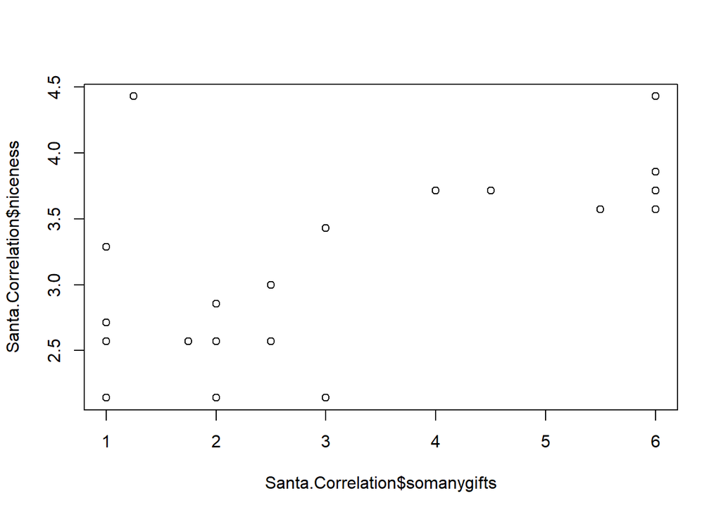

```r
plot(Santa.Correlation$somanygifts, Santa.Correlation$niceness)
```

## Regression

So now that we find a correlation between the two. Let’s ask the question: Does niceness predict overall gifts received?

```r
mymodel <- lm(somanygifts~niceness,Santa.Correlation)
```

sweeeet let’s find our more about our model by running a `summary` call on it.

```r
summary(mymodel)
```

```
##
## Call:
## lm(formula = somanygifts ~ niceness, data = Santa.Correlation)
##
## Residuals:
##     Min      1Q  Median      3Q     Max
## -4.2378 -0.6176  0.0605  1.2998  2.0444
##
## Coefficients:
##             Estimate Std. Error t value Pr(>|t|)
## (Intercept)  -2.4284     1.4814  -1.639  0.11679
## niceness      1.7875     0.4459   4.009  0.00069 ***
## ---
## Signif. codes:  0 '***' 0.001 '**' 0.01 '*' 0.05 '.' 0.1 ' ' 1
##
## Residual standard error: 1.533 on 20 degrees of freedom
##   (4 observations deleted due to missingness)
## Multiple R-squared:  0.4455, Adjusted R-squared:  0.4178
## F-statistic: 16.07 on 1 and 20 DF,  p-value: 0.0006896
```

Let’s try that plot again, but this time add a `abline` on it. a abline is simply a straight line through the plot. “AB” stands for the intercept and the slope.

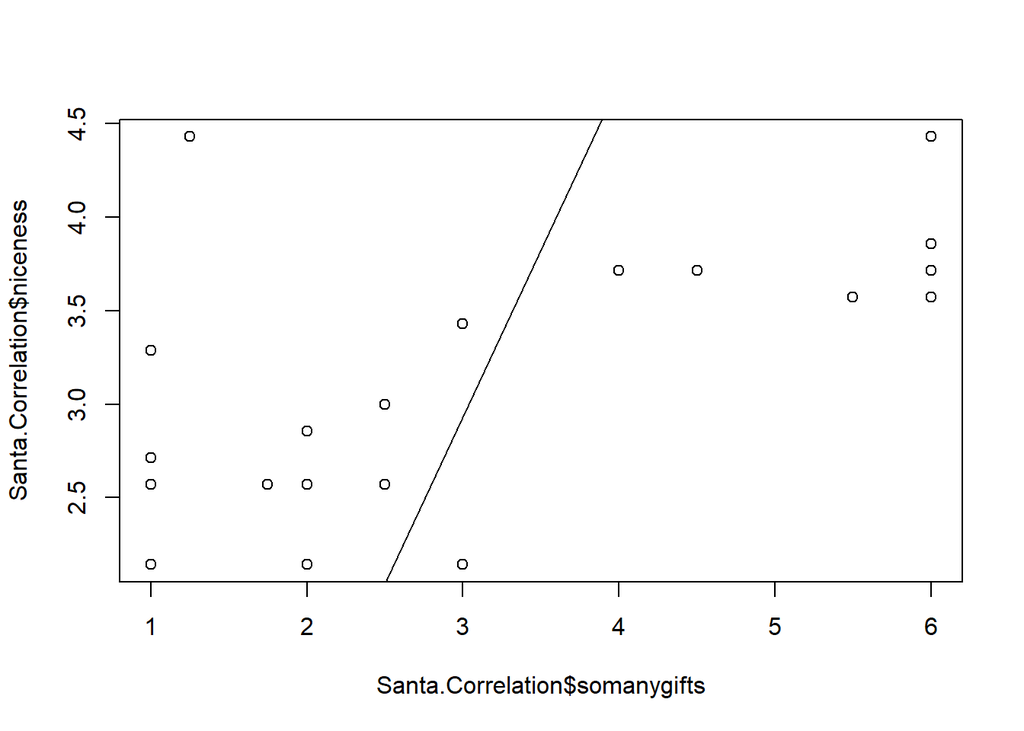

```r
plot(Santa.Correlation$somanygifts, Santa.Correlation$niceness)
abline(lm(somanygifts~niceness,Santa.Correlation))
```